# Has the Era of the Mega-Layoff Arrived? - WSJ

Page 1

[figure not shown]

**text found inside the figure**

https://www.wsj.com/business/has-the-era-of-the-mega-layoff-arrived-928f061d

BUSINESS **Has the Era of the Mega-Layoff Arrived?**

From Snap to Block to Amazon, a new template for ‘right sizing’ the workforce is spreading through C-suites—and other companies are taking note

By Chip Cutter

April 15, 2026 10:00 pm ET

GETTY IMAGES

Snap is laying off 16% of its staff. Block lopped off 40% of its workforce.

Oracle, meanwhile, is shedding thousands of employees, after Amazon.com

cut about 30,000 in a matter of months.

Welcome to the era of the mega-layoff. In Silicon Valley and beyond,

companies that are cutting staff are doing it with a big ax. Instead of laying

off people in more incremental—and less disruptive—waves, employers are

seizing on the potential financial upsides of severing swaths of their

workforces at once.

That is a departure from not long ago, when mass layoffs registered as a sign

of trouble or mismanagement and that a company needed to take drastic

Page 2

[figure not shown]

**text found inside the figure**

measures to right its performance. Now, such a company is more likely to

get a big stock bump and praise from investors for acting boldly.

Oracle cut tens of thousands of jobs last month. MICHAEL NAGLE/BLOOMBERG NEWS

Snap was no different. Though shares in the social-media company are down

23% over the past year, the company’s stock shot up 8% on Wednesday after

executives announced that it was eliminating 1,000 jobs.

Block shares had fallen 16% this year before it laid off 4,000, or nearly half, of

its employees in late February. The stock has since reversed those losses,

and then some.

Behind the scenes at Block, something else happened: Leaders from across

the corporate world messaged the payments company’s top executives,

asking for the playbook on how they might replicate such sweeping cuts at

their own companies, said Amrita Ahuja, Block’s chief financial officer and

chief operating officer.

“We had people kind of coming out of the woodwork,” Ahuja said in an

interview. Asked if she saw Block’s layoffs of 40% of its workforce as a new

template, she said: “It’s an inevitability. As a CFO, I think it’s better to be a

little bit early than to be too late here.”

The willingness to make the big cuts reflects a fundamental shift in how U.S.

companies view their professional talent. Instead of competing for

Page 3

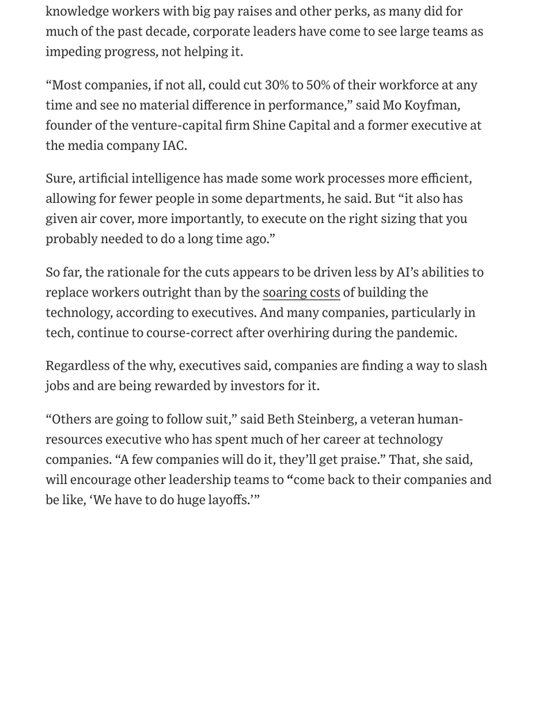

**text found inside the figure**

knowledge workers with big pay raises and other perks, as many did for

much of the past decade, corporate leaders have come to see large teams as

impeding progress, not helping it.

“Most companies, if not all, could cut 30% to 50% of their workforce at any

time and see no material difference in performance,” said Mo Koyfman,

founder of the venture-capital firm Shine Capital and a former executive at

the media company IAC.

Sure, artificial intelligence has made some work processes more efficient,

allowing for fewer people in some departments, he said. But “it also has

given air cover, more importantly, to execute on the right sizing that you

probably needed to do a long time ago.”

So far, the rationale for the cuts appears to be driven less by AI’s abilities to

replace workers outright than by the soaring costs of building the

technology, according to executives. And many companies, particularly in

tech, continue to course-correct after overhiring during the pandemic.

Regardless of the why, executives said, companies are finding a way to slash

jobs and are being rewarded by investors for it.

“Others are going to follow suit,” said Beth Steinberg, a veteran human-

resources executive who has spent much of her career at technology

companies. “A few companies will do it, they’ll get praise.” That, she said,

will encourage other leadership teams to “come back to their companies and

be like, ‘We have to do huge layoffs.’”

Page 4

[figure not shown]

**text found inside the figure**

Meta has had layoffs across several divisions in recent months. NOAH BERGER/AP

Among white-collar workers in tech and elsewhere, the angst is spreading.

Many college-educated workers are finding it increasingly difficult to find

new work after losing a job. Over the past 12 months, unemployment among

college-educated workers 34 and under has converged—and now surpassed

—the 4.1% rate for people with two-year associate degrees, according to an

analysis of Labor Department data by the economist Gad Levanon.

The “job-security premium of a bachelor’s degree has—at least for now—

disappeared,” he noted.

Michael Maximilien left his role as a distinguished engineer at International

Business Machines last year and has been building a new company,

ClawMax, to help people manage AI agents. He said he hears almost daily

from tech employees, some at large companies, checking to see if he is

hiring. So far, he isn’t.

He predicts many tech companies will cut teams by 20% to 50% by the end of

2026, if only because he is watching coding tools like Anthropic’s Claude

Code and OpenAI’s Codex advance so rapidly.

“I think I’ve met two people in 30 years that can do better than Claude Code

right now,” the 53-year-old said. “The models are getting better. So why

would I not, in a year, just get more Claude licenses instead of hiring

anybody?”

Page 5

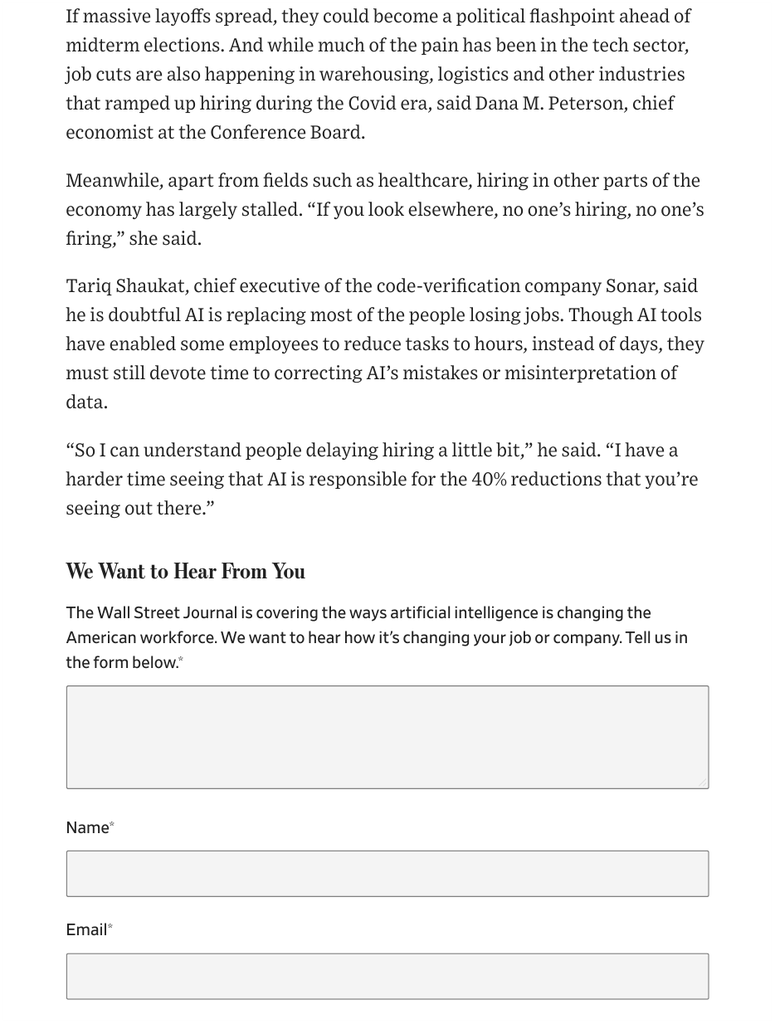

**text found inside the figure**

If massive layoffs spread, they could become a political flashpoint ahead of

midterm elections. And while much of the pain has been in the tech sector,

job cuts are also happening in warehousing, logistics and other industries

that ramped up hiring during the Covid era, said Dana M. Peterson, chief

economist at the Conference Board.

Meanwhile, apart from fields such as healthcare, hiring in other parts of the

economy has largely stalled. “If you look elsewhere, no one’s hiring, no one’s

firing,” she said.

Tariq Shaukat, chief executive of the code-verification company Sonar, said

he is doubtful AI is replacing most of the people losing jobs. Though AI tools

have enabled some employees to reduce tasks to hours, instead of days, they

must still devote time to correcting AI’s mistakes or misinterpretation of

data.

“So I can understand people delaying hiring a little bit,” he said. “I have a

harder time seeing that AI is responsible for the 40% reductions that you’re

seeing out there.”

**We Want to Hear From You**

The Wall Street Journal is covering the ways artificial intelligence is changing the American workforce. We want to hear how it’s changing your job or company. Tell us in the form below.*

Page 6

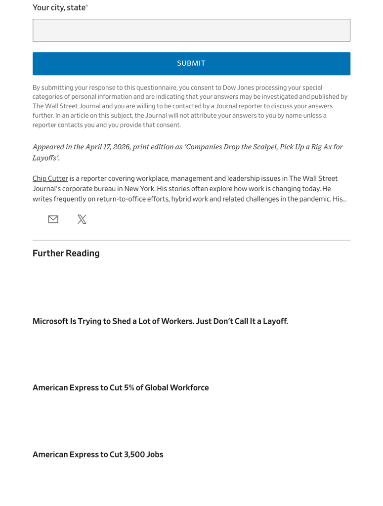

**text found inside the figure**

*Appeared in the April 17, 2026, print edition as 'Companies Drop the Scalpel, Pick Up a Big Ax for*

*Layoffs'.*

Further Reading

Page 7

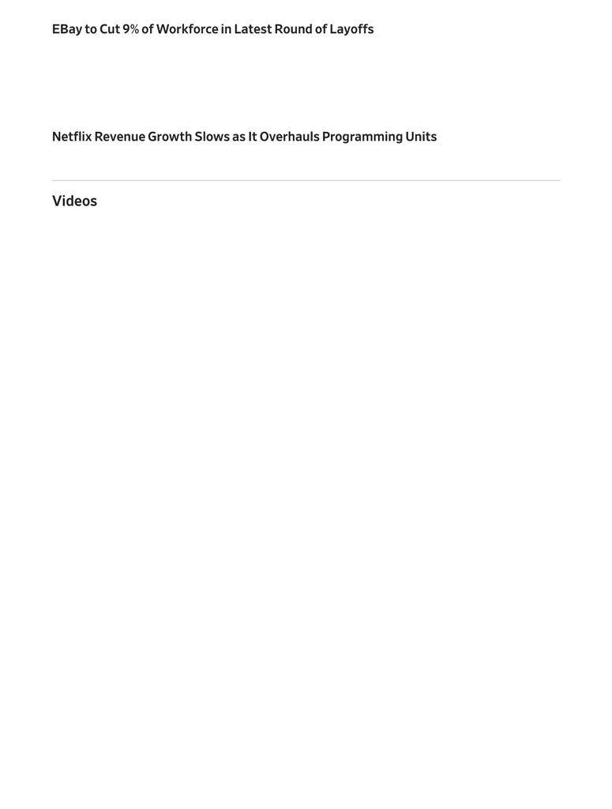

**text found inside the figure**

Videos